# Project_Survey_Data

The work-life balance score is based on research by Yvon Dalat in the 360 Living Guide. Over 14,000 people have taken the survey, which evaluates work-life balance in 5 modalities:

1. Healthy Body
2. Healthy Mind
3. Expertise
4. Connection
5. Meaning

```python
import pandas as pd
import numpy as np
import matplotlib.pyplot as plt
```

```python
df = pd.read_csv("wellbeing.csv")
```

```python
# show the top 15 rows of data
df.head(5)
```

|  | Timestamp | FRUITS_VEGGIES | DAILY_STRESS | PLACES_VISITED | CORE_CIRCLE | SUPPORTING_OTHERS | SOCIAL_NETWORK | ACHIEVEMENT | DONATION | BMI_RANGE | ... | SLEEP_HOURS | LOST_VACATION | DAILY_SHOUTING | SUFFICIENT_INCOME | PERSONAL_AWARDS | TIME_FOR_PASSION | WEEKLY_MEDITATION | AGE | GENDER | WORK_LIFE_BALANCE_SCORE |
| --- | --- | --- | --- | --- | --- | --- | --- | --- | --- | --- | --- | --- | --- | --- | --- | --- | --- | --- | --- | --- | --- |
| 0 | 7/7/15 | 3 | 2 | 2 | 5 | 0 | 5 | 2 | 0 | 1 | ... | 7 | 5 | 5 | 1 | 4 | 0 | 5 | 36 to 50 | Female | 609.5 |
| 1 | 7/7/15 | 2 | 3 | 4 | 3 | 8 | 10 | 5 | 2 | 2 | ... | 8 | 2 | 2 | 2 | 3 | 2 | 6 | 36 to 50 | Female | 655.6 |
| 2 | 7/7/15 | 2 | 3 | 3 | 4 | 4 | 10 | 3 | 2 | 2 | ... | 8 | 10 | 2 | 2 | 4 | 8 | 3 | 36 to 50 | Female | 631.6 |
| 3 | 7/7/15 | 3 | 3 | 10 | 3 | 10 | 7 | 2 | 5 | 2 | ... | 5 | 7 | 5 | 1 | 5 | 2 | 0 | 51 or more | Female | 622.7 |
| 4 | 7/7/15 | 5 | 1 | 3 | 3 | 10 | 4 | 2 | 4 | 2 | ... | 7 | 0 | 0 | 2 | 8 | 1 | 5 | 51 or more | Female | 663.9 |

5 rows × 24 columns

```python
# show descriptive stats for each column
df.describe()
```

|  | FRUITS_VEGGIES | PLACES_VISITED | CORE_CIRCLE | SUPPORTING_OTHERS | SOCIAL_NETWORK | ACHIEVEMENT | DONATION | BMI_RANGE | TODO_COMPLETED | FLOW | DAILY_STEPS | LIVE_VISION | SLEEP_HOURS | LOST_VACATION | DAILY_SHOUTING | SUFFICIENT_INCOME | PERSONAL_AWARDS | TIME_FOR_PASSION | WEEKLY_MEDITATION | WORK_LIFE_BALANCE_SCORE |
| --- | --- | --- | --- | --- | --- | --- | --- | --- | --- | --- | --- | --- | --- | --- | --- | --- | --- | --- | --- | --- |
| count | 15972.000000 | 15972.000000 | 15972.000000 | 15972.000000 | 15972.000000 | 15972.000000 | 15972.000000 | 15972.000000 | 15972.000000 | 15972.000000 | 15972.000000 | 15972.000000 | 15972.000000 | 15972.000000 | 15972.000000 | 15972.000000 | 15972.000000 | 15972.000000 | 15972.000000 | 15972.000000 |
| mean | 2.922677 | 5.232970 | 5.508077 | 5.616454 | 6.474267 | 4.000751 | 2.715314 | 1.410656 | 5.745993 | 3.194778 | 5.703606 | 3.752129 | 7.042888 | 2.898886 | 2.930879 | 1.728963 | 5.711558 | 3.326572 | 6.233346 | 666.751503 |
| std | 1.442694 | 3.311912 | 2.840334 | 3.242021 | 3.086672 | 2.755837 | 1.851586 | 0.491968 | 2.624097 | 2.357518 | 2.891013 | 3.230987 | 1.199044 | 3.692180 | 2.676301 | 0.444509 | 3.089630 | 2.729293 | 3.016571 | 45.019868 |
| min | 0.000000 | 0.000000 | 0.000000 | 0.000000 | 0.000000 | 0.000000 | 0.000000 | 1.000000 | 0.000000 | 0.000000 | 1.000000 | 0.000000 | 1.000000 | 0.000000 | 0.000000 | 1.000000 | 0.000000 | 0.000000 | 0.000000 | 480.000000 |
| 25% | 2.000000 | 2.000000 | 3.000000 | 3.000000 | 4.000000 | 2.000000 | 1.000000 | 1.000000 | 4.000000 | 1.000000 | 3.000000 | 1.000000 | 6.000000 | 0.000000 | 1.000000 | 1.000000 | 3.000000 | 1.000000 | 4.000000 | 636.000000 |
| 50% | 3.000000 | 5.000000 | 5.000000 | 5.000000 | 6.000000 | 3.000000 | 3.000000 | 1.000000 | 6.000000 | 3.000000 | 5.000000 | 3.000000 | 7.000000 | 0.000000 | 2.000000 | 2.000000 | 5.000000 | 3.000000 | 7.000000 | 667.700000 |
| 75% | 4.000000 | 8.000000 | 8.000000 | 10.000000 | 10.000000 | 6.000000 | 5.000000 | 2.000000 | 8.000000 | 5.000000 | 8.000000 | 5.000000 | 8.000000 | 5.000000 | 4.000000 | 2.000000 | 9.000000 | 5.000000 | 10.000000 | 698.500000 |
| max | 5.000000 | 10.000000 | 10.000000 | 10.000000 | 10.000000 | 10.000000 | 5.000000 | 2.000000 | 10.000000 | 10.000000 | 10.000000 | 10.000000 | 10.000000 | 10.000000 | 10.000000 | 2.000000 | 10.000000 | 10.000000 | 10.000000 | 820.200000 |

Let's look at the data in one more way - by count and data type.

```python
# get a different type of summary of the dataset
df.info()
```

```
<class 'pandas.core.frame.DataFrame'>
RangeIndex: 15972 entries, 0 to 15971
Data columns (total 24 columns):
 #   Column                   Non-Null Count  Dtype
---  ------                   --------------  -----
 0   Timestamp                15972 non-null  object
 1   FRUITS_VEGGIES           15972 non-null  int64
 2   DAILY_STRESS             15972 non-null  object
 3   PLACES_VISITED           15972 non-null  int64
 4   CORE_CIRCLE              15972 non-null  int64
 5   SUPPORTING_OTHERS        15972 non-null  int64
 6   SOCIAL_NETWORK           15972 non-null  int64
 7   ACHIEVEMENT              15972 non-null  int64
 8   DONATION                 15972 non-null  int64
 9   BMI_RANGE                15972 non-null  int64
```

[output cut: 16 more lines]

Uh oh, why is DAILY STRESS an object instead of a number. Let's look at what's stored there.

```python
df['DAILY_STRESS'].value_counts()
```

```
3         4398
2         3407
4         2960
1         2478
5         2052
0          676
1/1/00       1
Name: DAILY_STRESS, dtype: int64
```

### Impute value

Calculate the mean, median, and mode, and then use that to impute a reasonable value. If this question required someone to type an answer (as opposed to clicking an answer button), I might put more stock in the correct answer being 0 or 1. However, due to how the data was collected, this error must have happened when someone overwrote the response further down the line.

```python
# remove the response with the string
df_1 = df[-(df.DAILY_STRESS == "1/1/00")]

df_1.DAILY_STRESS = df_1.DAILY_STRESS.astype(int)
```

```python
df_1['DAILY_STRESS'].describe()
```

```
count    15971.000000
mean         2.791685
std          1.367801
min          0.000000
25%          2.000000
50%          3.000000
75%          4.000000
max          5.000000
Name: DAILY_STRESS, dtype: float64
```

The mean, median, and mode are all 3 (the mean is 2.8, but this is a whole number response value, so we'll round to a whole number). We'll use that to impute the incorrect error.

```python
# replace the string value with 3
df.DAILY_STRESS[(df.DAILY_STRESS == "1/1/00")] = 3

# convert daily_stress column to integers
df.DAILY_STRESS = df.DAILY_STRESS.astype(int)
```

```python
df.Timestamp.value_counts()
```

```
7/23/18          162
3/22/16          144
5/29/18          112
8/13/18           48
9/7/15            41
                ...
11/5/19 21:03      1
11/5/19 12:13      1
11/5/19 8:21       1
11/5/19 0:27       1
3/14/21 9:03       1
Name: Timestamp, Length: 7002, dtype: int64
```

Great. We have no nulls and all the data types make sense. Before we really get started, we should decide what to do about duplicates. Most of these responses are limited enough that two people could legitimately put in the same answers to every question. If that's the case, we don't want to delete.

If we pull up value_counts on the date column, something interesting happens - it's clear that in the beginning of this project, responses were being dumped into the systm en masse, and then later each line got its own datetime value. Because of the early date input system, we can't use the Timestamp column to identify duplicates.

Let's look at some characteristics of the Work Life Balance Score variable.

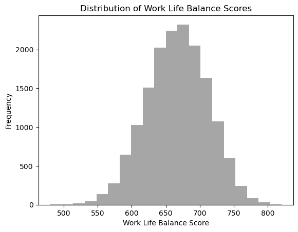

```python
# Create a histogram
plt.hist(df['WORK_LIFE_BALANCE_SCORE'], bins=20, color='gray', alpha=0.7)

# Add labels and title
plt.xlabel('Work Life Balance Score')
plt.ylabel('Frequency')
plt.title('Distribution of Work Life Balance Scores')

# Display the plot
plt.show()
```

```python
df['WORK_LIFE_BALANCE_SCORE'].describe()
```

```
count    15972.000000
mean       666.751503
std         45.019868
min        480.000000
25%        636.000000
50%        667.700000
75%        698.500000
max        820.200000
Name: WORK_LIFE_BALANCE_SCORE, dtype: float64
```

The mean score is 666.8, and the median is 667.7 (there's not a lot of skew here, which we can also see from the histogram). It looks normally distributed. The IQR is 62.5 and the standard deviation is 45.0, so the data doesn't spread much.

Nonetheless, let's look at three variables to see if they can be used on their own to predict work life balance score:

1. Age group
2. Gender
3. Sufficient Income

## Demographic breakdown

Let's start by seeing if there are differences in the work-life balance score based on the demographic categories participants entered.

```python
age_grouped = df.groupby('AGE')['WORK_LIFE_BALANCE_SCORE'].mean()
age_std = df.groupby('AGE')['WORK_LIFE_BALANCE_SCORE'].std()
print(age_grouped)
print(age_std)
# can we graph this
```

```
AGE
21 to 35        661.073936
36 to 50        667.251343
51 or more      677.712212
Less than 20    664.109951
Name: WORK_LIFE_BALANCE_SCORE, dtype: float64
AGE
21 to 35        43.746858
36 to 50        45.448966
51 or more      45.220870
Less than 20    44.006752
Name: WORK_LIFE_BALANCE_SCORE, dtype: float64
```

```python
age_groups = {'Age': ['Less than 20' , '21 to 35', '36 to 50', '51 or more'],
             'WLB_Score': [664.1, 661.1, 667.3, 677.7]}

age_groups = pd.DataFrame(age_groups)


print(age_groups, "\n")
```

```
            Age  WLB_Score
0  Less than 20      664.1
1      21 to 35      661.1
2      36 to 50      667.3
3    51 or more      677.7
```

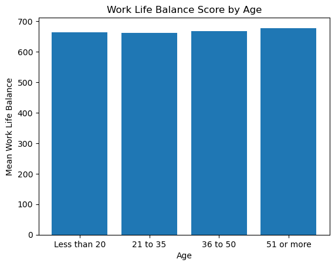

```python
# create a new figure for a plot
fig, ax = plt.subplots()

bar_chart = ax.bar(age_groups.Age, age_groups.WLB_Score)

ax.set_xlabel('Age')
ax.set_ylabel('Mean Work Life Balance')
ax.set_title('Work Life Balance Score by Age')
```

```python
# Creating a pivot table
#pivot_table = df.pivot_table(index='Category', columns='Value1', values='Value2', aggfunc='sum')
pivot_table = df.pivot_table(index='AGE', columns='GENDER', values='WORK_LIFE_BALANCE_SCORE', aggfunc='mean')
print(round(pivot_table, 1))
```

```
GENDER        Female   Male
AGE
21 to 35       662.0  659.8
36 to 50       669.0  664.2
51 or more     678.5  676.0
Less than 20   664.0  664.3
```

```python
print(pivot_table.min())
print(pivot_table.max())
```

```
GENDER
Female    662.017509
Male      659.772341
dtype: float64
GENDER
Female    678.510127
Male      676.048863
dtype: float64
```

Since I work in public health, I'm interested in the impact of poverty. One metric we often try to capture is the self-sufficiency income - the household income required to actually meet all the costs of living in your region.

Here, the survey authors simply asked the respondent - is your income sufficient?

I'm interested in identifying the largest differences in the survey populations between those who responded that their income was sufficient, and those who indicated it was not.

```python
# separate the data set into respondents with insufficient income, and respondents with sufficient income
ins = df[df.SUFFICIENT_INCOME == 1]
suff = df[df.SUFFICIENT_INCOME == 2]
```

```python
ins.describe()
```

|  | FRUITS_VEGGIES | DAILY_STRESS | PLACES_VISITED | CORE_CIRCLE | SUPPORTING_OTHERS | SOCIAL_NETWORK | ACHIEVEMENT | DONATION | BMI_RANGE | TODO_COMPLETED | ... | DAILY_STEPS | LIVE_VISION | SLEEP_HOURS | LOST_VACATION | DAILY_SHOUTING | SUFFICIENT_INCOME | PERSONAL_AWARDS | TIME_FOR_PASSION | WEEKLY_MEDITATION | WORK_LIFE_BALANCE_SCORE |
| --- | --- | --- | --- | --- | --- | --- | --- | --- | --- | --- | --- | --- | --- | --- | --- | --- | --- | --- | --- | --- | --- |
| count | 4329.000000 | 4329.000000 | 4329.000000 | 4329.000000 | 4329.000000 | 4329.000000 | 4329.000000 | 4329.000000 | 4329.000000 | 4329.000000 | ... | 4329.000000 | 4329.000000 | 4329.000000 | 4329.000000 | 4329.000000 | 4329.0 | 4329.000000 | 4329.000000 | 4329.000000 | 4329.000000 |
| mean | 2.571957 | 3.115962 | 4.273735 | 4.934858 | 5.013629 | 5.848233 | 3.486486 | 2.349041 | 1.420189 | 4.868792 | ... | 5.211134 | 3.103719 | 6.953800 | 3.398244 | 3.271425 | 1.0 | 4.942019 | 3.003696 | 5.859090 | 636.956826 |
| std | 1.438177 | 1.366501 | 3.256538 | 2.854676 | 3.260990 | 3.192141 | 2.668510 | 1.835771 | 0.493646 | 2.707962 | ... | 2.993640 | 3.072086 | 1.376859 | 3.885355 | 2.814591 | 0.0 | 3.043904 | 2.641728 | 3.158039 | 41.994783 |
| min | 0.000000 | 0.000000 | 0.000000 | 0.000000 | 0.000000 | 0.000000 | 0.000000 | 0.000000 | 1.000000 | 0.000000 | ... | 1.000000 | 0.000000 | 1.000000 | 0.000000 | 0.000000 | 1.0 | 0.000000 | 0.000000 | 0.000000 | 480.000000 |
| 25% | 1.000000 | 2.000000 | 2.000000 | 3.000000 | 2.000000 | 3.000000 | 1.000000 | 1.000000 | 1.000000 | 3.000000 | ... | 3.000000 | 1.000000 | 6.000000 | 0.000000 | 1.000000 | 1.0 | 3.000000 | 1.000000 | 3.000000 | 607.200000 |
| 50% | 2.000000 | 3.000000 | 4.000000 | 5.000000 | 5.000000 | 5.000000 | 3.000000 | 2.000000 | 1.000000 | 5.000000 | ... | 5.000000 | 2.000000 | 7.000000 | 2.000000 | 3.000000 | 1.0 | 5.000000 | 2.000000 | 6.000000 | 636.500000 |
| 75% | 4.000000 | 4.000000 | 6.000000 | 7.000000 | 8.000000 | 10.000000 | 5.000000 | 4.000000 | 2.000000 | 7.000000 | ... | 8.000000 | 5.000000 | 8.000000 | 7.000000 | 5.000000 | 1.0 | 7.000000 | 5.000000 | 9.000000 | 665.000000 |
| max | 5.000000 | 5.000000 | 10.000000 | 10.000000 | 10.000000 | 10.000000 | 10.000000 | 5.000000 | 2.000000 | 10.000000 | ... | 10.000000 | 10.000000 | 10.000000 | 10.000000 | 10.000000 | 1.0 | 10.000000 | 10.000000 | 10.000000 | 776.000000 |

8 rows × 21 columns

```python
suff.describe()
```

|  | FRUITS_VEGGIES | DAILY_STRESS | PLACES_VISITED | CORE_CIRCLE | SUPPORTING_OTHERS | SOCIAL_NETWORK | ACHIEVEMENT | DONATION | BMI_RANGE | TODO_COMPLETED | ... | DAILY_STEPS | LIVE_VISION | SLEEP_HOURS | LOST_VACATION | DAILY_SHOUTING | SUFFICIENT_INCOME | PERSONAL_AWARDS | TIME_FOR_PASSION | WEEKLY_MEDITATION | WORK_LIFE_BALANCE_SCORE |
| --- | --- | --- | --- | --- | --- | --- | --- | --- | --- | --- | --- | --- | --- | --- | --- | --- | --- | --- | --- | --- | --- |
| count | 11643.000000 | 11643.000000 | 11643.000000 | 11643.000000 | 11643.000000 | 11643.000000 | 11643.000000 | 11643.000000 | 11643.000000 | 11643.000000 | ... | 11643.000000 | 11643.000000 | 11643.000000 | 11643.000000 | 11643.00000 | 11643.0 | 11643.000000 | 11643.000000 | 11643.000000 | 11643.000000 |
| mean | 3.053079 | 2.671133 | 5.589625 | 5.721206 | 5.840591 | 6.707034 | 4.191961 | 2.851499 | 1.407112 | 6.072146 | ... | 5.886713 | 3.993215 | 7.076011 | 2.713218 | 2.80426 | 2.0 | 5.997681 | 3.446620 | 6.372498 | 677.829503 |
| std | 1.422546 | 1.348543 | 3.261221 | 2.805390 | 3.206303 | 3.013679 | 2.763419 | 1.838998 | 0.491317 | 2.515497 | ... | 2.830273 | 3.255464 | 1.124058 | 3.600276 | 2.61185 | 0.0 | 3.057584 | 2.751607 | 2.950305 | 40.890007 |
| min | 0.000000 | 0.000000 | 0.000000 | 0.000000 | 0.000000 | 0.000000 | 0.000000 | 0.000000 | 1.000000 | 0.000000 | ... | 1.000000 | 0.000000 | 1.000000 | 0.000000 | 0.00000 | 2.0 | 0.000000 | 0.000000 | 0.000000 | 537.000000 |
| 25% | 2.000000 | 2.000000 | 3.000000 | 4.000000 | 3.000000 | 4.000000 | 2.000000 | 1.000000 | 1.000000 | 4.000000 | ... | 4.000000 | 1.000000 | 6.000000 | 0.000000 | 1.00000 | 2.0 | 4.000000 | 1.000000 | 4.000000 | 649.600000 |
| 50% | 3.000000 | 3.000000 | 5.000000 | 5.000000 | 5.000000 | 7.000000 | 4.000000 | 3.000000 | 1.000000 | 7.000000 | ... | 6.000000 | 3.000000 | 7.000000 | 0.000000 | 2.00000 | 2.0 | 6.000000 | 3.000000 | 7.000000 | 677.900000 |
| 75% | 4.000000 | 4.000000 | 9.000000 | 8.000000 | 10.000000 | 10.000000 | 6.000000 | 5.000000 | 2.000000 | 8.000000 | ... | 8.000000 | 5.000000 | 8.000000 | 5.000000 | 4.00000 | 2.0 | 10.000000 | 5.000000 | 10.000000 | 705.800000 |
| max | 5.000000 | 5.000000 | 10.000000 | 10.000000 | 10.000000 | 10.000000 | 10.000000 | 5.000000 | 2.000000 | 10.000000 | ... | 10.000000 | 10.000000 | 10.000000 | 10.000000 | 10.00000 | 2.0 | 10.000000 | 10.000000 | 10.000000 | 820.200000 |

8 rows × 21 columns

At a glance, we can see that the group with sufficient income has higher mean scores on nearly every "positive" indicator, and lower mean scores on nearly every "negative" indicator.

We can construct a quick confidence interval by adding the standard deviation to the smaller mean in each group. That represents the top of a 68% confidence interval. If that range overlaps with the other group's mean, we know there is not a statistically significant difference between the two means. (We could use 3x the std to get a 95% confidence interval, but it turns out it's not necessary here).

Since the mean + std calculation always creates an overlap, we can tell this isn't a very useful distinction on its own.

### Conclusion

Overall, we found that it's hard to pick a specific demographic factor that seems to explain the limited variation we see. The next step would be to try a multivariate regression and see if combining multiple factors can do a better job of predicting someone's work life balance.

```python
!jupyter nbconvert --to html "Project - Survey Data.ipynb"
```

[output not shown]

[output cut: 132 more lines]

[output not shown]

[output not shown]